# 5 **Molecular Structure of Biological Molecules**

**Carbohydrates, Lipids, Proteins, Nucleic Acids, and Functional Groups**

Estimated Time: 2.5–3 hours

## 5.1 **Introduction: Molecular Structure of Biological Molecules**

Living organisms are composed of many organic molecules, most of which can be grouped into four major biological classes: **carbohydrates, lipids, proteins, and nucleic acids**. These molecules are central to life because they store energy, provide structural support, regulate cellular processes, form membranes, catalyze reactions, and carry genetic information.

Many biological molecules are built from smaller units. For example, simple sugars called **monosaccharides** may exist as individual molecules or join to form disaccharides and polysaccharides. **Amino acids** link together to form polypeptides and proteins. **Nucleotides** form nucleic acids such as DNA and RNA. Lipids are more chemically diverse; some contain fatty acids and glycerol, while others, such as sterols, contain fused carbon rings.

In this laboratory, you will examine molecular models and structural formulas representing the four major classes of biological molecules. You will identify functional groups, compare molecular structures, and relate structure to biological functions. As you work, focus on how atoms, bonds, polarity, molecular shape, and subunit arrangement influence what each molecule does in living systems.

For a direct and concise review of this topic you con review the following review on the macromolecules: [Macromolecules - Classes and Functions](https://youtu.be/V5hhrDFo8Vk?si=FMZE6Rc60Z9bBpFD) from the 2-Minute Classroom

**Learning Objectives**

By the end of this laboratory, students should be able to:

1. Identify the four major classes of biological molecules.
2. Recognize common subunits of carbohydrates, proteins, and nucleic acids.
3. Compare monosaccharides, disaccharides, and polysaccharides.
4. Distinguish among major lipid types, including fatty acids, triglycerides, phospholipids, and sterols.
5. Identify the general structure of an amino acid and explain the importance of the R group.
6. Describe the basic structure of nucleotides, DNA, and RNA.
7. Identify common functional groups in biological molecules.
8. Explain how molecular structure relates to biological functions.

**Terms to Define Before Lab**

Define the following terms before beginning the lab.

1. Organic molecule
2. Macromolecule
3. Monomer
4. Polymer
5. Functional group
6. Hydroxyl group
7. Carboxyl group
8. Amino group
9. Phosphate group
10. Monosaccharide
11. Disaccharide
12. Polysaccharide
13. Glycosidic linkage
14. Fatty acid
15. Triglyceride
16. Phospholipid
17. Sterol
18. Amino acid
19. Peptide bond
20. Nucleotide

## 5.2 **Pre-Lab Activity 4.1: Questions**

**Pre-Lab Questions:** Complete these questions before coming to the lab.

**Multiple Choice**

1. Which element forms the backbone of most biological organic molecules?  
   A. Sodium  
   B. Carbon  
   C. Chlorine  
   D. Potassium
2. Which class includes sugar and starches?  
   A. Lipids  
   B. Proteins  
   C. Carbohydrates  
   D. Nucleic acids
3. Which molecule is a monosaccharide?  
   A. Glucose  
   B. Sucrose  
   C. Starch  
   D. Cellulose
4. Amino acids are the monomers of:  
   A. Proteins  
   B. Lipids  
   C. Nucleic acids  
   D. Carbohydrates
5. Nucleotides are the monomers of:  
   A. Proteins  
   B. Nucleic acids  
   C. Lipids  
   D. Polysaccharides
6. Which molecule is a key component of cell membranes?  
   A. Phospholipid  
   B. Glucose  
   C. Amino acid  
   D. Cellulose
7. Which lipid has a four-ring carbon structure?  
   A. Triglyceride  
   B. Sterol  
   C. Phospholipid  
   D. Fatty acid
8. Which process breaks polymers by adding water?  
   A. Dehydration synthesis  
   B. Hydrolysis  
   C. Translation  
   D. Diffusion
9. Which biological molecule stores hereditary information?  
   A. DNA  
   B. Triglyceride  
   C. Starch  
   D. Cholesterol
10. Which functional group is commonly found in amino acids?  
    A. Amino group  
    B. Phosphate group only  
    C. Methyl group only  
    D. Sulfhydryl group only

**Short Answer**

11. What are the four major classes of biological molecules?
12. What is the difference between a monomer and a polymer?
13. What is a functional group?
14. Why is carbon especially important in biological molecules?
15. What atoms are commonly found in carbohydrates?
16. What is the difference between starch and cellulose?
17. What is the difference between a saturated and unsaturated fatty acid?
18. What does it mean for a molecule to be amphipathic?
19. What are the three parts of a nucleotide?
20. Why is molecular shape important in biology?

**Materials**

Each student or group should have:

- Lab handout
- Pencil or pen
- Colored pencils or highlighters
- Molecular model kit or instructor-provided molecular diagrams
- Textbook or approved course reference
- Ruler or straightedge
- Optional: digital molecular model viewer

**Laboratory Procedure**

## 5.3 **Part I. Carbohydrates: Sugars and Polysaccharides**

**Suggested Time: 35–40 minutes**

Carbohydrates are composed primarily of carbon, hydrogen, and oxygen. Many carbohydrates contain multiple hydroxyl groups, making them polar and often water-soluble. Carbohydrates may function as immediate energy sources, energy-storage molecules, or structural materials. This topic may be reviewed in “[Carbohydrates,; biological molecules simplified #1](https://youtu.be/PADu-fA7vfA?si=LgidDHhfx-r2JEPQ)”

**A. Monosaccharides: Glucose**

Glucose is a six-carbon monosaccharide with the molecular formula: C<sub>6</sub>H<sub>12</sub>O<sub>6</sub>

Glucose may be represented in a linear or ring form. Ring forms are common in aqueous environments. Different ring arrangements of glucose can produce structural isomers, such as alpha-glucose and beta-glucose.

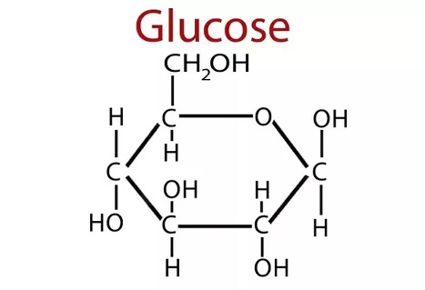

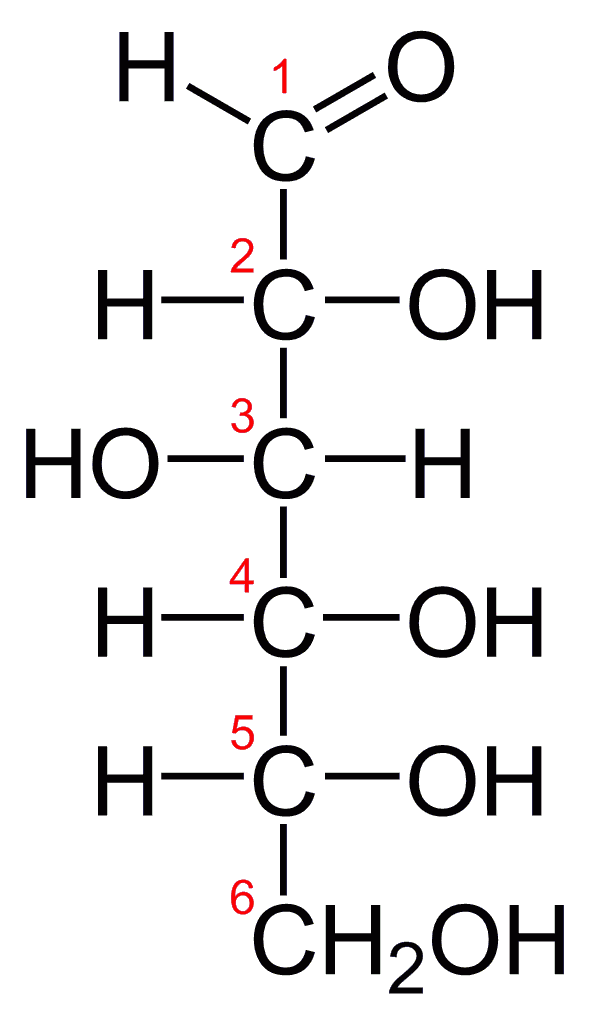

> Figure 4.1a: a glucose molecule Figure 4.11b: a linear glucose molecule

Two diagrams of glucose are shown: Figure 4.1a presents glucose as a ring-shaped molecule, while Figure 4.1b shows it as a straight-chain molecule, illustrating its two common forms.

**Figure 4.1a: Ring (cyclic) glucose molecule**  
A ring-shaped glucose molecule (C₆H₁₂O₆) is shown in its cyclic form, where the carbon chain has folded to form a six-membered ring. This occurs when the aldehyde group at carbon 1 reacts with the hydroxyl group on carbon 5. The ring consists of five carbon atoms and one oxygen atom, with hydroxyl (–OH) groups attached to the carbons. The position of the –OH group on carbon 1 distinguishes α- and β-glucose forms.

**Figure 4.1b: Linear glucose molecule**  
A linear glucose molecule (C₆H₁₂O₆) is shown in its open-chain form, consisting of a six-carbon backbone with an aldehyde group (–CHO) at carbon 1 and hydroxyl (–OH) groups attached to the remaining carbons. This structure can cyclize in solution to form the ring structure shown in Figure 4.1a.

Credits: Figure 4.1a & 4.1b: From https://www.nutrientsreview.com/wp-content/uploads/2014/09/Glucose-formula.jpg

**Guided Work**

Examine a glucose model or refer to the structural diagrams above.

1. Count the number of carbon atoms.
2. Count the number of oxygen atoms.
3. Identify the hydroxyl groups.
4. Explain whether hydroxyl groups are polar or nonpolar.
5. Compare alpha-glucose and beta-glucose. What structural differences do you observe?

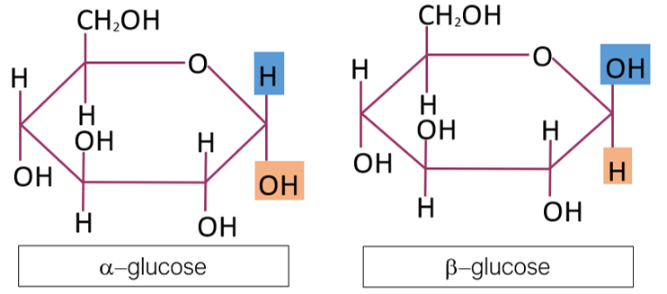

Carbohydrates - Karven Academy

> Figure 4.2: glucose isomers**: α-glucose and β-glucose (C<sub>6</sub>H<sub>12</sub>O<sub>6</sub>)**

**Figure 4.2** (Glucose Isomers: α-glucose and β-glucose):  
A diagram showing two ring-shaped glucose molecules labeled α-glucose and β-glucose (C₆H₁₂O₆). Both structures consist of six-membered rings made of carbon and oxygen atoms with attached hydroxyl (–OH) groups. The key difference is the orientation of the –OH group on carbon 1: in α-glucose it points downward, while in β-glucose it points upward. .

**B. Disaccharides: Sucrose**

Disaccharides form when two monosaccharides are joined by a **glycosidic linkage**. Sucrose is a common disaccharide composed of glucose and fructose.

During the formation of a disaccharide, water is removed. During breakdown of a disaccharide, water is added in a process called **hydrolysis**.

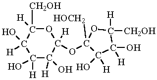

**Guided Work**

Examine a sucrose model.

1. How many monosaccharide units are present?
2. Which bond connects the two sugar units?
3. What molecule is needed to break sucrose apart by hydrolysis?
4. Is sucrose polar or nonpolar? Explain using functional groups.

**C. Polysaccharides: Starch and Cellulose**

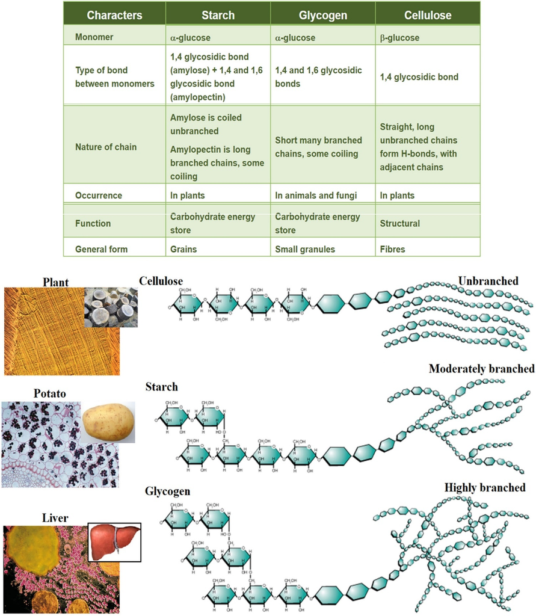

https://ars.els-cdn.com/content/image/1-s2.0-S0144861721010110-gr1_lrg.jpg

**Figure 4.4:** Naturally occurring [polysaccharides](https://www.sciencedirect.com/topics/chemistry/polysaccharide). Polysaccharides are giant polymers of monosaccharides. Polysaccharides of glucose: starch: storage of glucose in plants; cellulose: very stable, good for structural components. From F. Seidi, M. Yazdi, M. Jouyandeh, S. Habibzadeh, M. Munir, H. Vahabi, B. Bagheri, N. Rabiee, P. Zarrintaj, M. Saeb, Crystalline polysaccharides: A review, Carbohydrate Polymers, Vol. 275, 2022, https://doi.org/10.1016/j.carbpol.2021.118624. (https://www.sciencedirect.com/science/article/pii/S0144861721010110)

.

**Guided Work**

Compare starch and cellulose models.

1. Are the glucose chains branched or unbranched?
2. How does the linkage between glucose units differ?
3. Which molecule is better suited for energy storage?
4. Which molecule is better suited for structural support?
5. Why can two molecules made of glucose have different biological functions?

## 5.4 **Part II. Lipids: Fatty Acids, Triglycerides, Phospholipids, and Sterols**

**Suggested Time: 40–45 minutes**

Lipids are a diverse group of mostly hydrophobic molecules. Many contain long hydrocarbon regions, which make them poorly soluble in water. Lipids function in long-term energy storage, insulation, membrane structure, waterproofing, and chemical signaling. A brief introduction may be seen in the following video: “[Lipids | Fats, Steroids, and Phospholipids | Biological Molecules Simplified #4”](https://youtu.be/69-eGO7XDfU?si=6dSIsmtbzVqlXgYo)

**A. Fatty Acids**

Fatty acids contain a carboxyl group at one end and a hydrocarbon chain. A **saturated fatty acid** contains no carbon-carbon double bonds in its hydrocarbon chain. An **unsaturated fatty acid** contains one or more carbon-carbon double bonds, often producing bends in the chain.

**Fatty acids:**

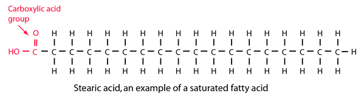

> http://hyperphysics.phy-astr.gsu.edu/hbase/Organic/imgorg/stearic.png

> Figure 4.5a: a saturated fatty acid

[figure not shown]

> http://hyperphysics.phy-astr.gsu.edu/hbase/Organic/imgorg/linoleic.png

> Figure 4.5b: an unsaturated fatty acid

Two diagrams compare fatty acids: one shows a saturated fatty acid with a straight carbon chain, and the other shows an unsaturated fatty acid with a bent chain due to a double bond.

**Figure 4.5a and 4.5b:** Comparison of Saturated and Unsaturated Fatty Acids

**Guided Work**

Examine saturated and unsaturated fatty acid models.

1. Circle or identify the carboxyl group.
2. Identify the hydrocarbon tail.
3. Compare the shape of saturated and unsaturated fatty acids.
4. Explain how double bonds affect molecular shape.

**B. Triglycerides**

A triglyceride contains one glycerol molecule joined to three fatty acids. Triglycerides are important for long-term energy storage molecules.

**TRIGLYCERIDES**

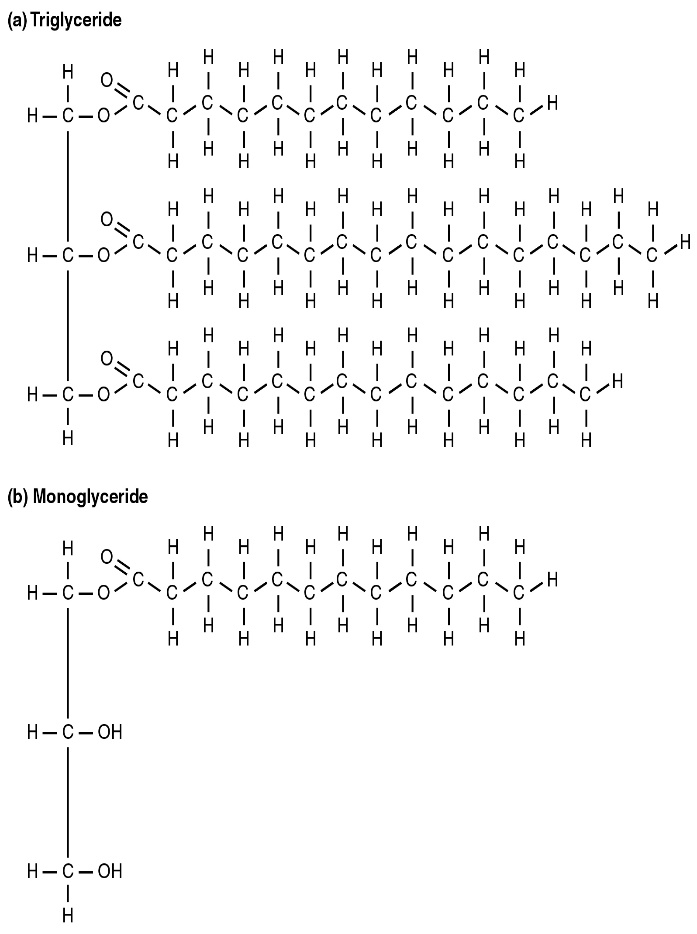

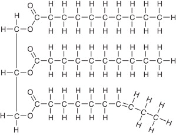

Figure 4.6a; a saturated fat Figure 4.6b an unsaturated fat

Two diagrams of fat molecules are shown: one stands for a saturated fat with straight fatty acid chains, and the other is an unsaturated fat with one or more bent chains due to double bonds.

**Figure 4.6a and b**. A saturated and unsaturated fat, respectively.

Credits: Figure 4.6 a: https://open.oregonstate.education/app/uploads/sites/48/2019/07/2511_A_Triglyceride_Molecule_a_Is_Broken_Down_Into_Monoglycerides_b.jpg. Figure 4.6b: A.H. Lichtenstein, 2013, Fats and Oils, Encyclopedia of Human Nutrition (Third Edition), Academic Press, Pages 201-208, https://doi.org/10.1016/B978-0-12-375083-9.00097-0. https://www.sciencedirect.com/science/article/pii/B9780123750839000970)

**Guided Work**

Examine a triglyceride model.

1. Identify and draw a circle around the glycerol backbone.
2. Identify and draw a box around the three fatty acid chains.
3. Predict the products of triglyceride hydrolysis. Write the products below.
4. Explain why triglycerides are mostly nonpolar.
5. Compare saturated and unsaturated triglycerides. Explain the differences below.

**C. Phospholipids**

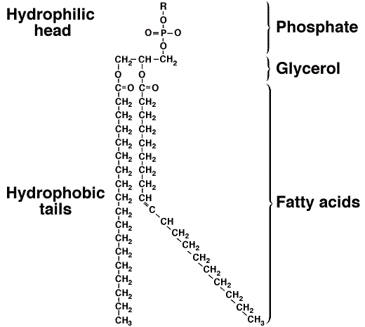

molecular structure of phospholipid Figure 2.

A diagram of a phospholipid molecule showing a polar head group and two nonpolar fatty acid tails. The head has a phosphate group, while the tails extend as long hydrocarbon chains, illustrating the molecule’s structure with a water-attracting (hydrophilic) head and water-repelling (hydrophobic) tails.

**Figure 4.7;** a phospholipid. From https://www.researchgate.net/profile/Ebrahim-Zahrabi/publication/297161568/figure/fig1/AS:336950331494401@1457346627123/molecular-structure-of-phospholipid-Figure-2.png

Phospholipids are major components of cell membranes. A phospholipid has a hydrophilic head region and hydrophobic fatty acid tails. Because it has both water-attracting and water-repelling regions, it is described as **amphipathic**.

**Guided Work**

Examine a phospholipid model.

1. Identify the phosphate-containing head. Draw a circle around it.
2. Identify the fatty acid tails.
3. Explain why the molecule is amphipathic.
4. Predict how phospholipids arrange themselves in water.
5. Explain why phospholipids are well suited for membrane formation.

**D. Sterols**

Sterols are lipids with a characteristic four-ring carbon framework. Cholesterol is the major sterol in animal cells. It contributes to membrane structure and serves as a precursor for several important molecules, including steroid hormones and vitamin D.

**Guided Work**

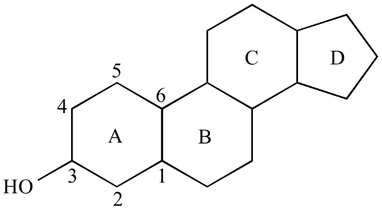

[figure not shown]

**Figure 4.8a.** a general sterol molecule model **Figure 4.8b.** cholesterol

Two diagrams of sterol molecules are shown: one illustrates a general sterol structure with four fused carbon rings, and the other shows cholesterol with a similar ring structure and a short hydrocarbon tail.

Credits: Figure 4.8a: From *Steven A. Hardinger, “*Illustrated Glossary of Organic Chemistry”, *Department of Chemistry & Biochemistry, UCLA* https://www.chem.ucla.edu/~harding/IGOC/S/sterol01.png. Figure 4.8b from https://www.nutrientsreview.com/wp-content/uploads/2014/12/Cholesterol-structure.jpg

Examine a cholesterol or sterol model.

1. Count the number of fused rings. How many are there?
2. Identify any polar functional group in the general sterol model?
3. Is cholesterol mostly polar or mostly nonpolar?
4. Where is cholesterol found in animal cells?
5. Why is cholesterol biologically important?

## 5.5 **Part III. Proteins: Amino Acids and Polypeptides**

**Suggested Time: 35–40 minutes** **PROTEINS: Pages 75-83**

Proteins are polymers made of amino acid monomers. Each amino acid contains a central carbon attached to an amino group, a carboxyl group, a hydrogen atom, and an R group. The R group differs among amino acids and determines many of their chemical properties.

Amino acids are joined by peptide bonds to form polypeptides. The amino acid sequence influences how the protein folds, and the folded shape determines protein function. For a quick review please visit the following video: “[Proteins, Biological Molecules simplified #2”](https://youtu.be/mEROyfRxbFM?si=Py4gt7dfXwW6B3IZ)

1. **Amino Acid Structure**

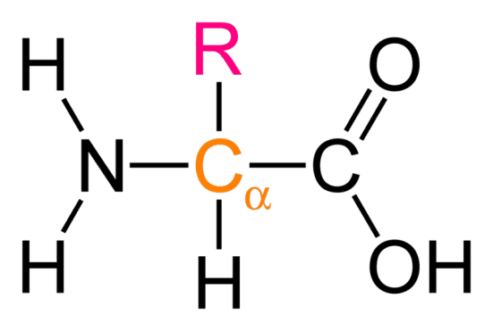

> How are alpha amino acids different from beta amino acids? - Quora

**Alt text:**

A diagram of a general amino acid showing a central carbon atom bonded to an amino group (–NH₂), a carboxyl group (–COOH), a hydrogen atom, and a variable side chain (R group).

**Figure 4.9** (Amino Acid): (obtained from Quora https://qph.fs.quoracdn.net/main-qimg-6e5fc1022752632bbe80515b295f4440)

Examine a general amino acid model.

1. Find the amino group. Draw a ring around this structure.
2. Locate the carboxyl group. Draw a box around this structure.
3. Identify the central carbon.
4. Find the R group.
5. From your review of amino acids in your textbook, describe why the R group is significant.

**B. Amino Acid Categories**

Table 4.1. Examples of amino acids based on the R-group structural differences.

| **Category** | **Example Amino Acid** |
| --- | --- |
| Nonpolar |  |
| Polar |  |
| Acidic |  |
| Basic |  |

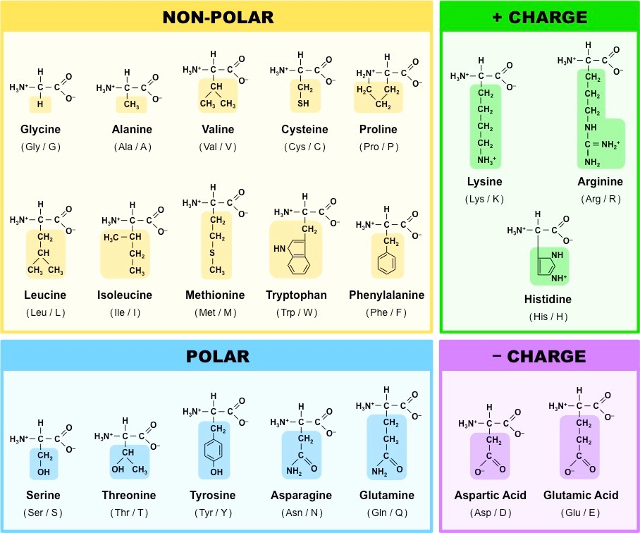

My Image 1

A chart displaying the 20 standard amino acids found in proteins, each shown with its chemical structure. The amino acids share a common backbone but differ in their side chains (R groups), which vary in size, shape, and chemical properties.

**Figure 4.10**: the 20 amino acids of proteins. From https://ib.bioninja.com.au/_Media/amino-acid-structures_med.jpeg

**C. Polypeptides**

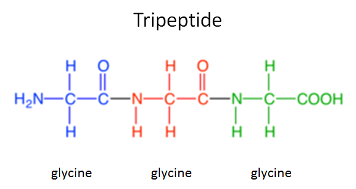

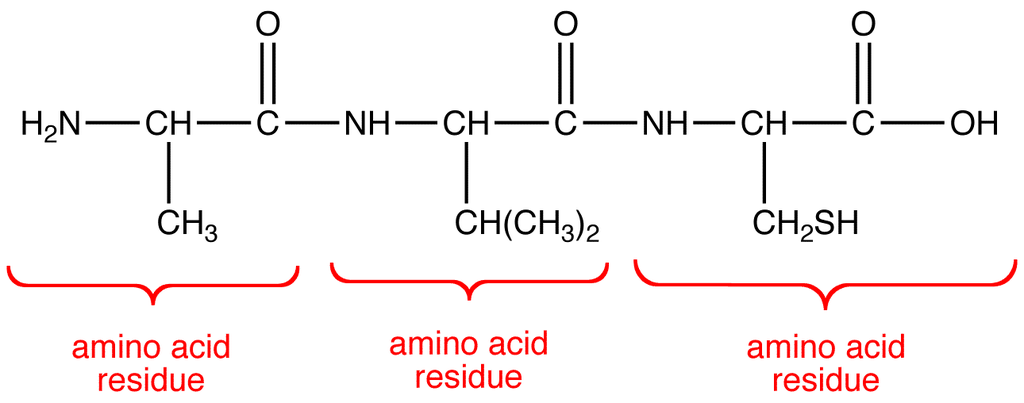

**Figure 4.11a:** diagram of polypeptide “a” **Figure 4.11b:** diagram of polypeptide “b”

Two diagrams of polypeptides are shown: one (4.11a) illustrates a chain of amino acids linked together by peptide bonds, and the other (4.11b) shows a similar chain in a slightly different arrangement, highlighting how amino acids connect to form protein structures. A credit line lists sources from Quora and Ochempal.

Credits: figure 4.11a: Quora; https://qph.cf2.quoracdn.net/main-qimg-aa8d4ec5c5e5c108bfec85724cbb89f3. Figure 4.11b by Gamini Gunawardena; http://www.ochempal.org/wp-content/images/O/oligopeptide.png.

Examine the short polypeptide model in the figures above.

## 5.6 **Part IV. Nucleic Acids: Nucleotides, DNA, and RNA**

**Suggested Time: 35–40 minutes** **NUCLEIC ACIDS** **Pages 84-87, 260**

Nucleic acids store and transmit genetic information. DNA and RNA are polymers made of nucleotide monomers. Each nucleotide contains a phosphate group, a five-carbon sugar, and a nitrogenous base.

DNA contains deoxyribose and the bases adenine, thymine, cytosine, and guanine. RNA contains ribose and the bases of adenine, uracil, cytosine, and guanine. A brief introduction to this topic may be found in “[What are Nucleic Acids? Nucleic Acid Structure & Function](https://youtu.be/lm14Les80Tk?si=-CBX6D4UbcOEWI3h)”.

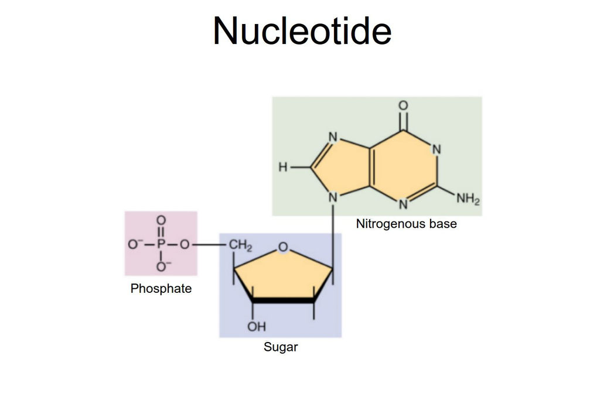

Nucleic Acids - Function, Examples, and Monomers

A diagram showing the structure of nucleotides, each composed of three parts: a phosphate group, a sugar, and a nitrogenous base.

**Figure 4.12:** Nucleotides (OpenStax/Wikimedia Commons/CC BY-SA 3.0)

**A. Nucleotide Structure**

Examine a nucleotide model of diagram.

1. Identify the phosphate group.
2. Identify the sugar.
3. Identify the nitrogenous base.
4. Explain how nucleotides are linked to a nucleic acid strand.

**B. DNA Structure**

DNA has a sugar-phosphate backbone and paired nitrogenous bases. The two strands are antiparallel, meaning they run in opposite directions.

Base-pairing rules:

- A pair with T
- C pairs with G

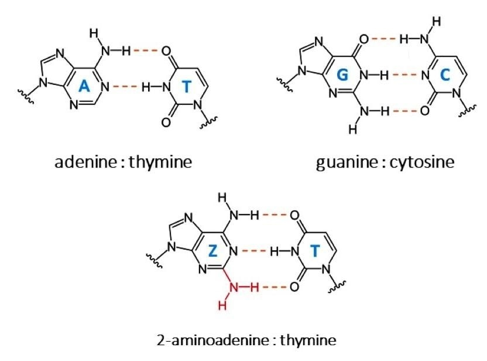

> Researchers identify the biosynthesis mechanism of new DNA nucleobases

A diagram illustrating the bonding pattern between a purine and a pyrimidine base, showing how the two nitrogen-containing rings align and form complementary base pairs through hydrogen bonds. From Sleiman, D., *et al.* (2021) A third purine biosynthetic pathway encoded by amino adenine-based viral DNA genomes. *Science*. doi.org/10.1126/science.abe6494.

**Fig. 4.13:** bonding pattern of a puring end pyrimidine.

**DNA**

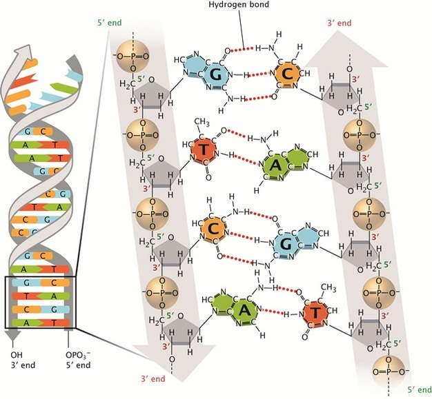

In a schematic illustration, a region of double-stranded, double helical DNA is shown at the left. The two sugar-phosphate backbones are represented as grey ribbons coiled into a double helical shape. Arrows at the end of the grey ribbons show how one strand is oriented in an antiparallel manner relative to the other strand. A cut-away at the bottom of the DNA molecule on the left shows a magnified view of the molecule at the right, with individual atoms, covalent bonds, and hydrogen bonds shown. The magnified region is four base pairs long.

A diagram of a DNA molecule showing the double helix structure with two strands twisted around each other, along with a close-up of a partial chemical strand highlighting the sequence of nucleotides and their bonding. Nature Education 1(1):100

**Figure 4.14,** a DNA molecule, and a partial DNA chemical strand. Credit: Pray, L. (2008). Discovery of DNA structure and function: Watson and Crick.

**Guided Work**

1. Identify the sugar-phosphate backbone. Circle this.
2. Identify paired bases. Draw a box around these.
3. Distinguish purines from pyrimidines. Label the purines (Pu) and the pyrimidines (Pyr).
4. Explain how pairing a purine with a pyrimidine helps keep the width of DNA consistent.
5. Count the hydrogen bonds between A-T and C-G pairs. How many did you find between each pair?

**C. RNA Compared with DNA**

RNA differs from DNA in three major ways: RNA usually has ribose sugar, contains uracil instead of thymine, and is usually single-stranded.

**RNA: Page 271**

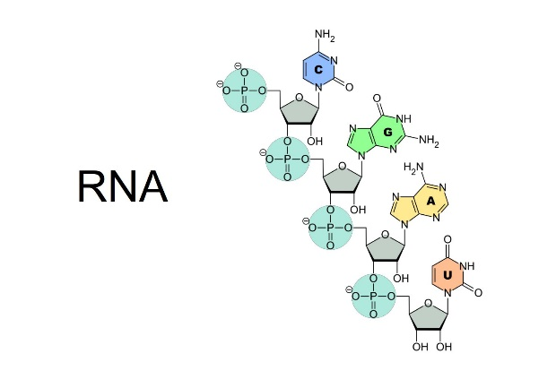

> Nucleic Acids - Function, Examples, and Monomers

A diagram of an RNA strand showing a single chain of nucleotides, each made of a sugar, phosphate group, and nitrogenous base, illustrating the linear structure of RNA.

**Figure 4.15 RNA strand** from Online Education Resources, LLC © 2017; https://www.scienceprofonline.com/images/RNA-Nucleobases.jpg

Complete the comparison table.

**Table 4.2. Comparison Table: DNA vs RNA**

| **Feature** | **DNA** | **RNA** |
| --- | --- | --- |
| Sugar |  |  |
| Bases |  |  |
| Usual number of strands |  |  |
| Major function |  |  |

## 5.7 **Part V. Functional Groups in Biological Molecules**

**Suggested Time: 25–30 minutes** **FUNCTIONAL GROUPS: pgs. 62-63**

Functional groups are specific groups of atoms that give molecules characteristic chemical properties. They influence polarity, acidity, charge, solubility, and reactivity. For a video on functional groups see the following video: “[Functional Groups Explained so AP Bio Students can Understand!](https://youtu.be/3rqmBK1VA_I?si=IjiQActdjHFxiCkO)”

**Complete the table.**

**Table** **4.3. Functional Groups: Structure, Examples, and Biological Importance**

| **Functional Group** | **General Structure** | **Example of Molecule/Class** **Where Found** | **Biological Importance** |
| --- | --- | --- | --- |
| Hydroxyl |  |  |  |
| Carboxyl |  |  |  |
| Amino |  |  |  |
| Phosphate |  |  |  |
| Methyl |  |  |  |

## 5.8 **Part VI. Synthesis: Structure Determines Function**

**Suggested Time: 15–20 minutes**

Choose one molecule from each class and explain how its structure supports its function.

**Table 4.4. Examples of biological molecules’ features and function(s)**

| **Biological Molecule** | **Structural Feature** |  | **Biological Function** |
| --- | --- | --- | --- |
| Carbohydrate example |  |  |  |
| Lipid example |  |  |  |
| Protein example |  |  |  |
| Nucleic acid example |  |  |  |

**Final Reflection**

In one well-developed paragraph, explain why structure is essential to biological function.

## 5.9 **Post-Lab Questions**

**Multiple Choice**

1. Which molecule is a monosaccharide?  
   A. Glucose  
   B. Protein  
   C. Cholesterol  
   D. DNA
2. Which molecule is a structural polysaccharide in plants?  
   A. Starch  
   B. Cellulose  
   C. Glycogen  
   D. Sucrose
3. Which bond joins monosaccharides?  
   A. Peptide bond  
   B. Glycosidic linkage  
   C. Hydrogen bond  
   D. Ionic bond
4. Which molecule is composed of glycerol and three fatty acids?  
   A. Phospholipid  
   B. Triglyceride  
   C. Sterol  
   D. Nucleotide
5. A molecule with both hydrophilic and hydrophobic regions is:  
   A. Amphipathic  
   B. Saturated  
   C. Inorganic  
   D. Linear only
6. Which lipid contains four fused carbon rings?  
   A. Fatty acid  
   B. Phospholipid  
   C. Sterol  
   D. Triglyceride
7. Which part of an amino acid varies among the 20 common amino acids?  
   A. Amino group  
   B. Carboxyl group  
   C. R group  
   D. Central carbon only
8. Which bond joins amino acids?  
   A. Glycosidic linkage  
   B. Peptide bond  
   C. Phosphodiester bond  
   D. Disulfide only
9. Which molecule has deoxyribose?  
   A. RNA  
   B. DNA  
   C. Protein  
   D. Triglyceride
10. In DNA, adenine pairs with:  
    A. Cytosine  
    B. Guanine  
    C. Thymine  
    D. Uracil

**Short Answer**

11. Explain why glucose is considered a carbohydrate monomer.
12. Compare starch and cellulose in structure and function.
13. Why are hydroxyl groups hydrophilic?
14. Explain the difference between saturated and unsaturated fatty acids

.

15. Why are triglycerides useful for long-term energy storage?
16. Explain why phospholipids form bilayers in water.
17. Why is cholesterol an important molecule in animal cells?
18. Describe the general structure of an amino acid.
19. Explain how the R group influences amino acid properties.
20. Compare DNA and RNA in terms of sugar, bases, strand numbers, and function.

## 5.10 **Student Ancillaries**

**MolView**

MolView is an easy-to-use chemical sketcher and viewer for small molecules. Explore the molecular world and get creative through this intuitive web app!

https://molview.com/.

## 5.11 **Appendix: Molecular Structure of Biological Molecules**

| **Term** | **Definition** |
| --- | --- |
| Amino Acid | A molecule containing an amino group, carboxyl group, hydrogen, and variable R group; building blocks of proteins. |
| Amino Group | A functional group (-NH2) consisting of nitrogen bonded to hydrogen; found in amino acids. |
| Amphipathic | Having both hydrophilic (water-attracting) and hydrophobic (water-repelling) regions. |
| Carbohydrate | A biological molecule composed of carbon, hydrogen, and oxygen, used for energy and structure. |
| Carboxyl Group | A functional group (-COOH) that acts as an acid and is found in many organic molecules. |
| Disaccharide | A carbohydrate formed by two monosaccharides linked together by a glycosidic bond. |
| Fatty Acid | A lipid component consisting of a carboxyl group and a long hydrocarbon chain. |
| Functional Group | A specific group of atoms that gives a molecule its chemical properties. |
| Glycosidic Linkage | A covalent bond that joins two monosaccharides in a carbohydrate. |
| Hydrolysis | A chemical reaction that breaks bonds by adding water. |
| Hydroxyl Group | A functional group (-OH) that is polar and increases solubility in water. |
| Lipid | A group of hydrophobic biological molecules including fats, phospholipids, and sterols. |
| Macromolecule | A large biological molecule composed of many smaller subunits. |
| Monomer | A small molecular subunit that can join with others to form a polymer. |
| Monosaccharide | A single sugar molecule, such as glucose; the simplest form of carbohydrate. |
| Nucleic Acid | A macromolecule (DNA or RNA) that stores and transmits genetic information. |
| Nucleotide | The monomer of nucleic acids, consisting of a phosphate group, sugar, and nitrogenous base. |
| Peptide Bond | A covalent bond that links amino acids together in proteins. |
| Phosphate Group | A functional group (PO4) involved in energy transfer and found in nucleotides. |
| Phospholipid | A lipid with a hydrophilic head and hydrophobic tails that forms cell membranes. |
| Polymer | A large molecule made of repeating monomer units. |
| Polysaccharide | A carbohydrate composed of many linked monosaccharides. |
| Protein | A macromolecule made of amino acid chains that performs various cellular functions. |
| R Group | The variable side chain of an amino acid that determines its properties. |
| Saturated Fatty Acid | A fatty acid with no double bonds, resulting in a straight chain. |
| Sterol | A lipid with a four-ring carbon structure, such as cholesterol. |
| Triglyceride | A lipid composed of glycerol and three fatty acids, used for energy storage. |
| Unsaturated Fatty Acid | A fatty acid containing one or more double bonds causing bends in the chain. |